# Spam Detection

NLP

code

NLP

Natural Language, Processing

Python, R

Author

Simone Brazzi

Published

September 5, 2024

# 1 Introduction

Tasks:

- Train a model to classify spam.
- Find the main topic in the spam emails.
- Calculate semantic distance of the spam topics.
- Extract the ORG from ham emilas.

# 2 Import

## 2.1 R libraries

```r
library(tidyverse, verbose = FALSE)
library(ggplot2)
library(gt)
library(reticulate)
library(plotly)

renv::use_python("/Users/simonebrazzi/venv/blog/bin/python3")
```

## 2.2 Python packages

```python
import pandas as pd
import numpy as np
import spacy
import nltk
import string
import gensim
import gensim.corpora as corpora
import gensim.downloader

from nltk.corpus import stopwords
from gensim.models import Word2Vec
from scipy.spatial.distance import cosine
from sklearn.metrics.pairwise import cosine_similarity

from sklearn.feature_extraction.text import TfidfVectorizer
from sklearn.neural_network import MLPClassifier
from sklearn.model_selection import train_test_split
from sklearn.metrics import classification_report

from collections import Counter
# glove vector
glove_vector = gensim.downloader.load("glove-wiki-gigaword-300")
# nltk stopwords
nltk.download('stopwords')
stop_words = stopwords.words('english')
```

## 2.3 Config class

```python
class Config():
  def __init__(self):

    """
    CLass initialize function.
    """

    self.path="/Users/simonebrazzi/R/blog/posts/spam_detection/spam_dataset.csv"
    self.random_state=42

  def get_lemmas(self, doc):

    """
    List comprehension to get lemmas. It performs:\n
      1. Lowercase.\n
      2. Stop words removal\n.
      3. Whitespaces removal.\n
      4. Remove the word 'subject'.\n
      5. Digits removal.\n
      6. Get only words with length >= 5.\n
    """

    lemmas = [
      [
        t.lemma_ for t in d
        if (text := t.text.lower()) not in punctuation
        and text not in stop_words
        and not t.is_space
        and text != "subject"
        and not t.is_digit
        and len(text) >=5
        ]
        for d in doc
        ]
    return lemmas

  def get_entities(self, doc):

    """
    List comprehension to get the lemmas which have entity type 'ORG'.
    """

    entities = [
    [
      t.lemma_ for t in d
      if (text := t.text.lower()) not in punctuation
      and text not in stop_words
      and not t.is_space
      and text != "subject"
      and not t.is_digit
      and len(text) >=5
      and t.ent_type_ == "ORG"
      ]
      for d in doc
      ]
    return entities

  def get_sklearn_mlp(self, activation, solver, max_iter, hidden_layer_sizes, tol):

    """
    It initialize the sklearn MLPClassifier.
    """

    mlp = mlp = MLPClassifier(
      activation=activation,
      solver=solver,
      max_iter=max_iter,
      hidden_layer_sizes=hidden_layer_sizes,
      tol=tol,
      verbose=True
      )
    return mlp

  def get_lda(self, corpus, id2word, num_topics, passes, workers, random_state):

    """
    Initialize LDA.
    """

    lda = gensim.models.LdaMulticore(
      corpus=corpus,
      id2word=id2word,
      num_topics=num_topics,
      passes=passes,
      workers=workers,
      random_state=self.random_state
      )
    return lda

config = Config()
```

# 3 Dataset

```python
df = pd.read_csv(config.path, index_col=0)
```

To further perform analysis also in R, here we assign the df to a variable using `reticulate` library.

```r
library(reticulate)
df <- py$df
```

## 3.1 EDA

First things first, Exploratory Data Analysis. Considering we are going to perform a classification, is interesting to check if our dataset is unbalanced.

```r
df_g <- df %>%
  summarise(
    freq_abs = n(),
    freq_rel = n() / nrow(df),
    .by = label
    )

df_g %>%
  gt() %>%
  fmt_auto() %>%
  cols_width(
    label ~ pct(20),
    freq_abs ~ pct(35),
    freq_rel ~ pct(35)
    ) %>%
  cols_align(
    align = "center",
    columns = c(freq_abs, freq_rel)
  ) %>%
  tab_header(
    title = "Label frequency",
    subtitle = "Absolute and relative frequencies"
  ) %>%
  cols_label(
    label = "Label",
    freq_abs = "Absolute frequency",
    freq_rel = "Relative frequency"
  ) %>%
  tab_options(
    table.width = pct(100)
    )
```

[output not shown]

It is useful also a visual cue.

```r
g <- ggplot(df_g) +
  geom_col(aes(x = freq_abs, y = label, fill = label)) +
  scale_fill_brewer(palette = "Set1", direction = -1) +
  theme_minimal() +
  ggtitle("Absolute frequency barchart") +
  xlab("Absolute frequency") +
  ylab("Label") +
  labs(fill = "Label")
ggplotly(g)
```

[output not shown]

# 4 Preprocessing

In case of text, the preprocessing is fundamental: the computer does not understand the semantic or grammatical meaning of words. In case of text preprocessing, we follow the following steps:

1. Lowercasing.
2. Punctuation removal.
3. Lemmatization.
4. Tokenization.
5. Stopwords removal.

Using `SpaCy`, we can applied these steps. The method `nlp.pipe` improves the performance and returns a generator. It yields a `Doc` objects, not a list. To use it as a list, it has to be defined as such. To speed up the process, is it possible to enable the multi process method in `nlp.pipe`. But, what does the variable `nlp` stand for? It load a spaCy model: we are going to use the `en_core_web_lg`.

- **Language**: EN; english.
- **Type**: CORE; vocabulary, syntax, entities, vectors
- **Genre**: WEB; written text (blogs, news, comments).
- **Size**: LG; large (560 mB).

Check this [link](https://spacy.io/models/en) for the documentation about this model.

I had chosen this model, even if it is the biggest, to get the full potential of it.

```python
# load en_core_web_lg
nlp = spacy.load("en_core_web_lg")
doc = list(nlp.pipe(df.text, n_process=4))
```

The specific preprocessing in this case should check these steps:

1. Remove punctuation.
2. Remove stop words.
3. Remove spaces.
4. Remove *“subject”* token.
5. Lemmatization.

To improve code performance, these are the most noticible points:

- When iterating over a collection of unique elements, **`set()`** performs better then `list()`. The underlying hash table structure allows for swift traversal. This is particularly noticible when the df dimension increase.
- **List comprehension**, which performs better then for loops and are much more readable in some context.
- The **walrus operator** `:=`. It is a syntax which lets assign variables in the middle of expressions. It avoids redundant calculations and improves readability.

```python
punctuation = set(string.punctuation)
stop_words = set(stop_words)

lemmas = config.get_lemmas(doc)
entities = config.get_entities(doc)

# assignment to a df column
df["lemmas"] = lemmas
df["entities"] = entities
```

# 5 Tasks

## 5.1 Classification

The text is already preprocessed as list of lemmas. For the classification task, it is necessary to convert it as a string.

```python
df["feature"] = df.lemmas.apply(lambda x : " ".join(x))
```

### 5.1.1 Features

As said, the machine does not understand human readable text. It has to be transformed. The best approach is to **vectorize** it with `TfidfVectorizer()`. It is a tool for converting text into a matrix of TF-IDF features. The **T**erm**F**requency-**I**nverse**D**ocument**F**requency is a statistical method. It is a measure of importance of a word in a document, part of a corpus, adjusted for the frequency in the corpus. The model vectorize a word by multiplying the word **T**erm **F**requency

$$TF = \frac{word\ frequency\ in\ document}{total\ words\ in\ document}$$
with the **I**nverse **D**ocument **F**requency

$$IDF = log(\frac{total\ number\ documents}{documents\ containing\ the\ word})$$
The final result is

$$TF-IDF = TF * IDF$$

The resulting **score** represents the importance of a word. It dependes on the word frequency both in a specific document and in the corpus.

**Note**

An example can be useful. If a word t appears 20 times in a document of 100 words, we have

$$TF = \frac{20}{100}=0.2$$

If there are 10.000 documents in the corpus and 100 documents contains the term t

$$IDF = log(\frac{10000}{100})=2$$

This means the score is

$$TF-IDF=0.2*2=0.4$$

```python
vectorizer = TfidfVectorizer()
X = vectorizer.fit_transform(df['feature'])
y = df.label
```

## 5.2 Split

Not much to say about this: a best practice which let evaluate the performance of our model on new data.

```python
xtrain, xtest, ytrain, ytest = train_test_split(X, y, test_size=.2, random_state=42)
```

### 5.2.1 Model

The model is the `MLPClassifier()`. It is a Multi Perceptron Layer Classifier.

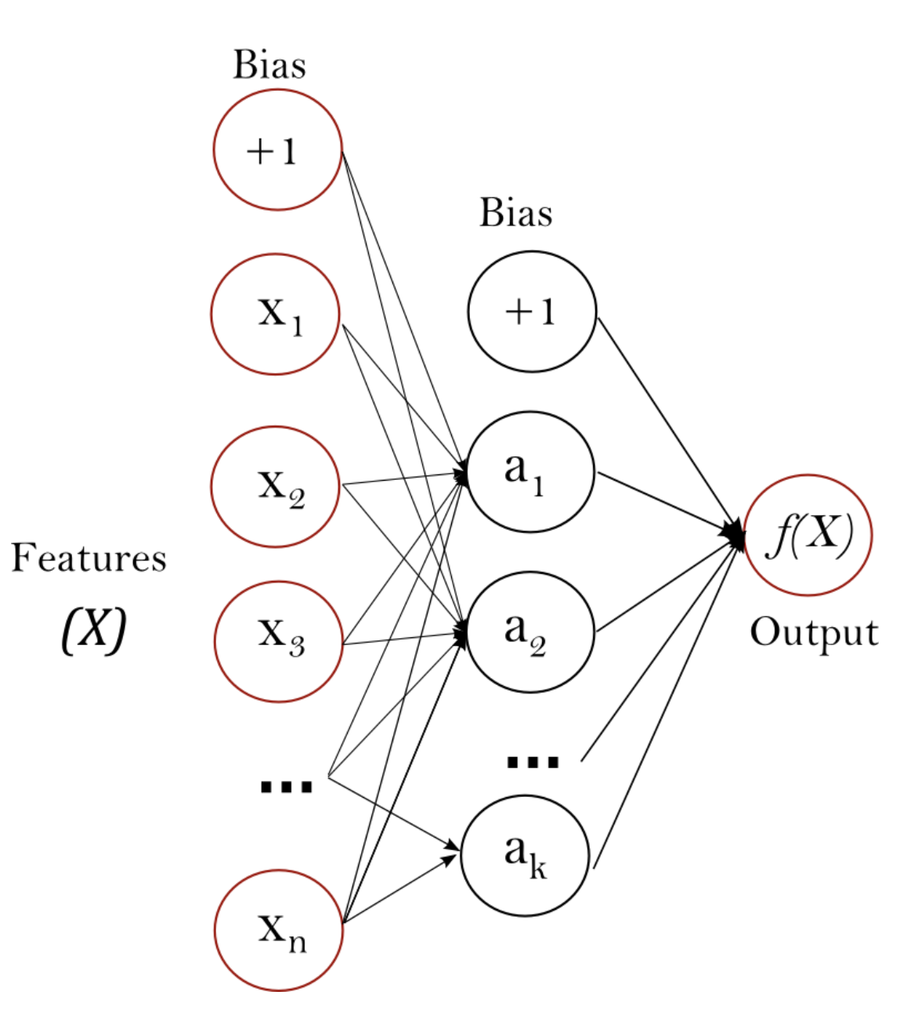

MLPClassifier

It is an Artificial Neural Network used for classification. It consists of **multiple layers of nodes**, called **perceptrons**. For further reading, see the [documentation](https://scikit-learn.org/stable/modules/neural_networks_supervised.html).

```python
mlp = config.get_sklearn_mlp(
  activation="logistic",
  solver="adam",
  max_iter=100,
  hidden_layer_sizes=(100,),
  tol=.005
  )
```

### 5.2.2 Fit

```python
mlp.fit(xtrain, ytrain)
```

### 5.2.3 Predict

```python
ypred = mlp.predict(xtest)
```

### 5.2.4 Classification report

Considering we are doing a classificatoin, one method to evaluate the performance is the classification report. It summarize the performance of the model comparing **true** and **predicted** labels, showing not only the metrics (precision, recall and F1-score) but also the support.

```python
cr = classification_report(
  ytest,
  ypred,
  target_names=["spam", "ham"],
  digits=4,
  output_dict=True
  )
df_cr = pd.DataFrame.from_dict(cr).reset_index()
```

```r
library(reticulate)

df_cr <- py$df_cr %>% dplyr::rename(names = index)
cols <- df_cr %>% colnames()
df_cr %>%
  pivot_longer(
    cols = -names,
    names_to = "metrics",
    values_to = "values"
  ) %>%
  pivot_wider(
    names_from = names,
    values_from = values
  ) %>%
  gt() %>%
  tab_header(
    title = "Confusion Matrix",
    subtitle = "Sklearn MLPClassifier"
  ) %>%
  fmt_number(
    columns = c("precision", "recall", "f1-score", "support"),
    decimals = 2,
    drop_trailing_zeros = TRUE,
    drop_trailing_dec_mark = FALSE
  ) %>%
  cols_align(
    align = "center",
    columns = c("precision", "recall", "f1-score", "support")
  ) %>%
  cols_align(
    align = "left",
    columns = metrics
  ) %>%
  cols_label(
    metrics = "Metrics",
    precision = "Precision",
    recall = "Recall",
    `f1-score` = "F1-Score",
    support = "Support"
  )
```

[output not shown]

## 5.3 Topic Modeling for spam content

Topic modeling in nlp can count on the **L**atent **D**irilicht **M**odel. It is a generative model used to get the topics which occur in a set of documents.

The LDA model has:

- Input: a **corpus** of text documents, preprocessed as tokenized and cleaned words. We have this in the *lemmas* column.
- Output: a **distribution** of topics for each document and one of words for each topic.

### 5.3.1 Dataset

Filter data to have a spam dataframe and create a variable with the lemmas column to work with.

```python
spam = df[df.label == "spam"]
x = spam.lemmas
```

### 5.3.2 Create corpus

LDA algortihm needs the corpus as a **bag of word**.

```python
id2word = corpora.Dictionary(x)
corpus = [id2word.doc2bow(t) for t in x]
```

### 5.3.3 Model

The model will return a user defined number of topics. For each of it, it will return a user defined number of words ad the probability of each of them.

```python
lda = config.get_lda(
  corpus=corpus,
  id2word=id2word,
  num_topics=10,
  passes=10, # number of times the algorithm see the corpus
  workers=4, # parellalize
  random_state=42
  )
topic_words = lda.show_topics(num_topics=10, num_words=5, formatted=False)

# Iterate over topic_words to extract the data
data = []
data = [
    (topic, w, p)
    for topic, words in topic_words
    for w, p in words
    ]
topics_df = pd.DataFrame(data, columns=['topic', 'word', 'proba'])
```

```r
py$topics_df %>%
  gt() %>%
  tab_header(
    title = "Words and probabilities by topics"
  ) %>%
  fmt_auto() %>%
  cols_width(
    topic ~ pct(33),
    word ~ pct(33),
    proba ~ pct(33)
    ) %>%
  cols_align(
    align = "center",
    columns = c(topic, word, proba)
  ) %>%
  cols_label(
    topic = "Topic",
    word = "Word",
    proba = "Probability"
  ) %>%
  tab_options(
    table.width = pct(100)
  )
```

[output not shown]

## 5.4 Semantic distance between topics

The semantic distance requires a documents made of strings. Using a `dict`, we can extract the topics and the words. The dict has the topics as keys and the words as a list of words. The documents can be created using the `.join()`.

```python
topics_dict = {}
for topics, words in topic_words:
  topics_dict[topics] = [w[0] for w in words]

documents = [" ".join(words) for words in topics_dict.values()]
```

```python
vectorizer = TfidfVectorizer()
tfidf_matrix = vectorizer.fit_transform(documents)
cosine_sim_matrix = cosine_similarity(tfidf_matrix, dense_output=True)
topics = list(topics_dict.keys())
cosine_sim_df = pd.DataFrame(cosine_sim_matrix, index=topics, columns=topics)
```

```r
py$cosine_sim_df %>%
  gt() %>%
  fmt_auto() %>%
  cols_align(
    align = "center",
    columns = c(`0`, `1`, `2`, `3`, `4`, `5`, `6`, `7`, `8`, `9`)
  ) %>%
  cols_label(
    `0` = "Topic 0",
    `1` = "Topic 1",
    `2` = "Topic 2",
    `3` = "Topic 3",
    `4` = "Topic 4",
    `5` = "Topic 5",
    `6` = "Topic 6",
    `7` = "Topic 7",
    `8` = "Topic 8",
    `9` = "Topic 9",
  ) %>%
  tab_options(
    table.width = pct(100)
    )
```

[output not shown]

## 5.5 Organization of “HAM” mails

### 5.5.1 Create “HAM” df

### 5.5.2 Get ham lemmas which have ORG entity

```python
ham = df[df.label == "ham"]
x = ham.entities
```

```python
from collections import Counter

# Flatten the list of lists and create a Counter object
d = Counter([i for e in x for i in e])

freq_df = pd.DataFrame(d.items(), columns=["word", "freq"])
```

```r
library("wordcloud")
library("RColorBrewer")

set.seed(42)
word_freqs_df <- py$freq_df

wordcloud(
  words = word_freqs_df$word,
  freq = word_freqs_df$freq,
  min.freq = 1,
  max.words = 100, # nrow(word_freqs_df),
  random.order = FALSE,
  rot.per = .3,
  colors = brewer.pal(n = 8, name = "Dark2")
  )
```

[output not shown]

```r
word_freqs_df %>%
  arrange(desc(freq)) %>%
  head(10) %>%
  gt() %>%
  tab_header(
    title = "Top 10 ham words ",
    subtitle = "by frequency"
  ) %>%
  fmt_auto() %>%
  cols_width(
    word ~ pct(50),
    freq ~ pct(50)
    ) %>%
  cols_align(
    align = "center",
    columns = c(word, freq)
  ) %>%
  cols_label(
    word = "Word",
    freq = "Frequency"
  ) %>%
  tab_options(
    table.width = pct(100)
  )
```

[output not shown]